# Pertemuan 4 Praktikum MPDW

## Karakteristik AR(2)

### Plot Time Series

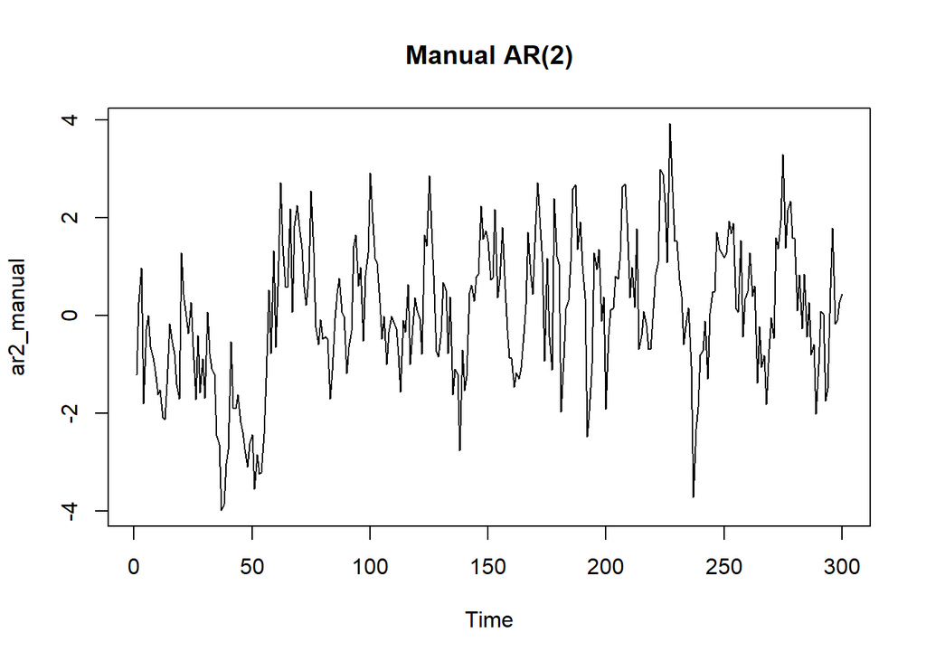

```r
ts.plot(ar2_manual, main="Manual AR(2)")
```

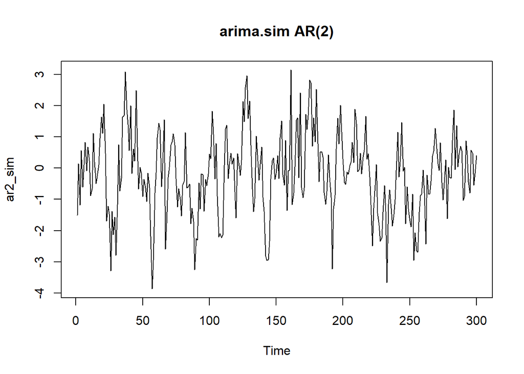

```r
ts.plot(ar2_sim, main="arima.sim AR(2)")
```

Berdasarkan plot time series tersebut terlihat bahwa data cenderung stasioner pada rataan

### Plot ACF

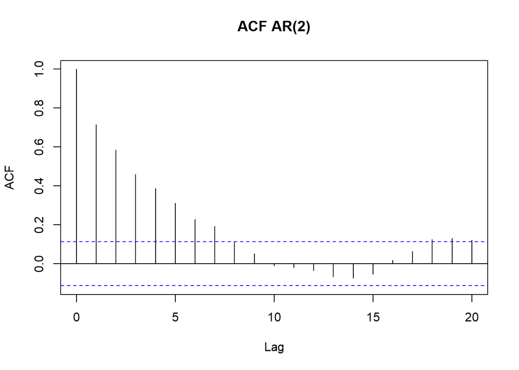

```r
acf(ar2_manual, lag.max=20, main="ACF AR(2)")
```

Berdasarkan plot ACF tersebut terlihat bahwa plot ACF cenderung *tails off* dan cenderung membentuk pola grafik sinus

### Plot PACF

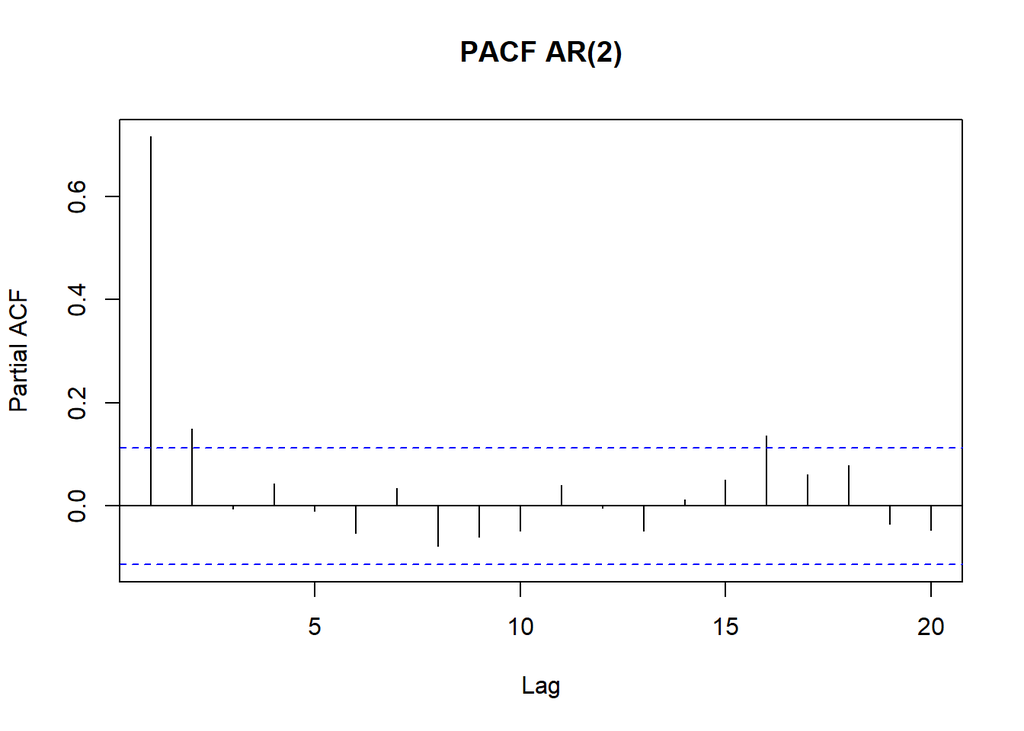

```r
pacf(ar2_manual, lag.max=20, main="PACF AR(2)")
```

Berdasarkan plot PACF tersebut, terlihat bahwa plot PACF *cuts off* pada lag kedua, sejalan dengan teori yang ada

### Plot EACF

```r
TSA::eacf(ar2_manual)
```

```
## AR/MA
##   0 1 2 3 4 5 6 7 8 9 10 11 12 13
## 0 x x x x x x x o o o o  o  o  o
## 1 x o o o o o o o o o o  o  o  o
## 2 o o o o o o o o o o o  o  o  o
## 3 x x o o o o o o o o o  o  o  o
## 4 x x o o o o o o o o o  o  o  o
## 5 x x o x o o x o o o o  o  o  o
## 6 x x x x o o o o o o o  o  o  o
## 7 x x x o x x o o o o o  o  o  o
```

Berdasarkan pola segitiga nol pada plot EACF, terlihat bahwa segitiga nol berada pada ordo AR(2) dan ordo MA(0)

## Scatterplot Antar Lag

### Korelasi antara $Y_t$ dengan $Y_{t-1}$

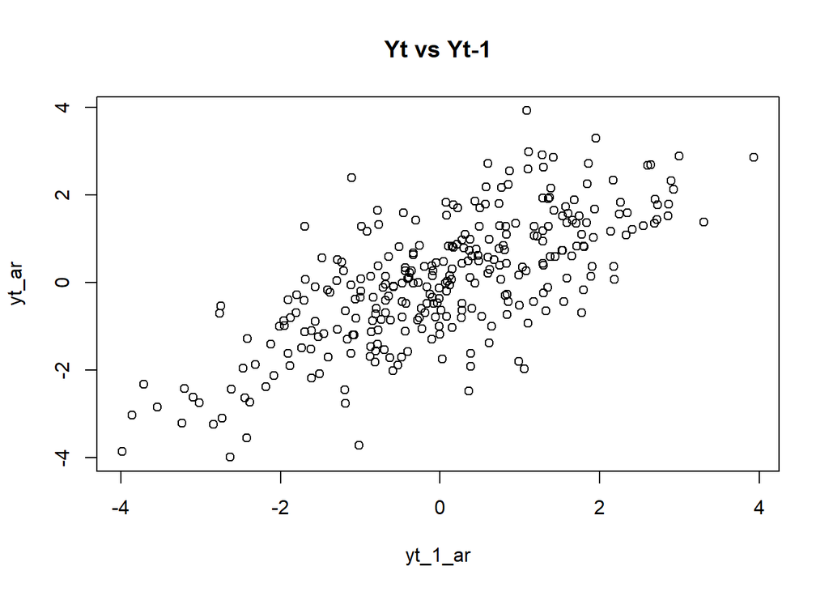

```r
yt_ar <- ar2_manual[-1]
yt_1_ar <- ar2_manual[-n]
plot(x=yt_1_ar, y=yt_ar, main="Yt vs Yt-1")
```

```r
cor(yt_ar, yt_1_ar)
```

```
## [1] 0.7165728
```

Korelasi antara $Y_t$ dengan $Y_{t-1}$ dari hasil simulasi mendekati perhitungan teoritis yaitu $\rho_1=\phi^1=0.625$

### Korelasi antara $Y_t$ dengan $Y_{t-2}$

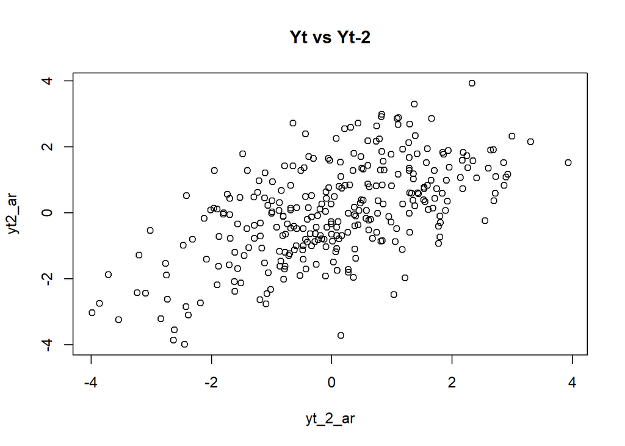

```r
yt2_ar <- ar2_manual[-c(1,2)]
yt_2_ar <- ar2_manual[-c((n-1), n)]
plot(x=yt_2_ar, y=yt2_ar, main="Yt vs Yt-2")
```

```r
cor(yt2_ar, yt_2_ar)
```

```
## [1] 0.5856318
```

Korelasi antara $Y_t$ dengan $Y_{t-2}$ dari hasil simulasi mendekati perhitungan teoritis yaitu $\rho_2=\phi^2=0.5125$

### Korelasi antara $Y_t$ dengan $Y_{t-3}$

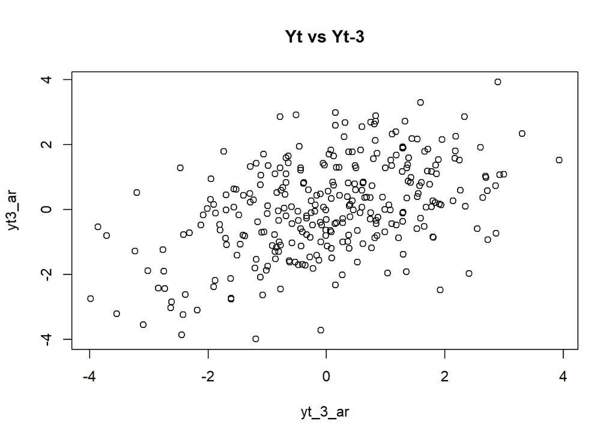

```r
yt3_ar <- ar2_manual[-c(1,2,3)]
yt_3_ar <- ar2_manual[-c((n-2), (n-1), n)]
plot(x=yt_3_ar, y=yt3_ar, main="Yt vs Yt-3")
```

```r
cor(yt3_ar, yt_3_ar)
```

```
## [1] 0.4609517
```

Korelasi antara $Y_t$ dengan $Y_{t-3}$ dari hasil simulasi mendekati perhitungan teoritis yaitu $\rho_3=\phi^3=0.38125$

## Autokorelasi

```r
acf(ar2_manual, lag.max=10, plot=FALSE)$acf
```

```
## , , 1
##
##               [,1]
##  [1,]  1.000000000
##  [2,]  0.715577739
##  [3,]  0.584767799
##  [4,]  0.459945692
##  [5,]  0.386173207
##  [6,]  0.310563930
##  [7,]  0.228938747
##  [8,]  0.191524707
##  [9,]  0.116051367
## [10,]  0.052196288
## [11,] -0.009810566
```

```r
acf(ar2_sim, lag.max=10, plot=FALSE)$acf
```

```
## , , 1
##
##              [,1]
##  [1,] 1.000000000
##  [2,] 0.601007134
##  [3,] 0.415378655
##  [4,] 0.298599079
##  [5,] 0.197404616
##  [6,] 0.059608267
##  [7,] 0.012341537
##  [8,] 0.023914100
##  [9,] 0.016421253
## [10,] 0.006715185
## [11,] 0.034950870
```

# 3. Bangkitkan model ARMA(2,2) dengan $\theta1 = 0.4$ & $\theta2 = 0.6$ & $\phi1 = 0.5$ & $\phi2 = 0.2$ sebanyak 300 data (Manual dan dengan arima.sim)

## Pembangkitan Data Manual

```r
set.seed(1234)
n <- 300
wn <- rnorm(n)
arma22_manual <- rep(0, n)
arma22_manual[1:2] <- wn[1:2]
for(i in 3:n){
  arma22_manual[i] <- 0.5*arma22_manual[i-1] + 0.2*arma22_manual[i-2] + wn[i] + 0.4*wn[i-1] + 0.6*wn[i-2]
}
arma22_manual
```

```
##   [1] -1.20706575  0.27742924  0.36847490 -1.50574039 -0.53766490 -1.29969338
##   [7] -0.87222246 -1.16894421 -1.88686532 -2.62101924 -2.85976172 -3.67737093
##  [13] -3.87256190 -3.51682974 -2.01340200 -1.39787953 -1.08104743 -2.00187014
##  [19] -2.72540011 -0.22882482 -0.06137315  0.93599896 -0.10064445  0.12583632
##  [25] -0.73142392 -1.79048404 -1.46228520 -2.75191579 -1.74816209 -2.98066156
##  [31] -1.12112807 -1.75293957 -1.33899414 -2.09047491 -3.56829700 -4.32225497
##  [37] -6.49933032 -7.02769676 -6.95242937 -6.26996504 -3.43890746 -3.74182948
##  [43] -2.97182019 -3.49823048 -3.96328734 -4.21591391 -4.99194239 -5.61517573
##  [49] -5.49498973 -5.32810275 -6.08211743 -5.70927767 -6.49640107 -6.19781948
##  [55] -5.63181806 -4.16631812 -1.43386859 -1.32659086  1.33518960 -0.57718012
##  [61]  1.13545868  2.56923464  2.89049817  2.80495292  1.68426167  2.77538382
##  [67]  1.29220743  3.17981523  3.04188012  3.84589813  3.47054592  2.25362466
##  [73]  1.27634579  1.31729358  3.02358708  2.83893413  1.81428668  0.10302896
##  [79] -0.45121970 -0.85290753 -0.66635425 -0.93510416 -2.14779642 -2.08562341
##  [85] -1.51503473 -0.24121274  0.91556687  0.64537308  0.48311177 -1.14217407
```

[output cut: 35 more lines]

## Pembangkitan Data dengan arima.sim

```r
arma22_sim <- arima.sim(list(order=c(2,0,2), ar=c(0.5, 0.2), ma=c(0.4, 0.6)), n=n)
arma22_sim
```

```
## Time Series:
## Start = 1
## End = 300
## Frequency = 1
##   [1] -2.0296272586  0.1804874357 -1.0857429326  0.2019685297  0.5101006237
##   [6]  0.3116647978  1.1440157679  0.4568971792 -0.3804875233 -0.8758133113
##  [11]  0.3166261152  0.2548874061  0.2592079202 -0.3290331722 -0.2948120396
##  [16]  0.8417548499  2.0860897066  2.3426969416  3.4797265438  1.9702862497
##  [21] -0.2703838028 -1.6091794075 -2.9699033669 -4.6121759676 -3.5735246545
##  [26] -4.6576056483 -3.2455887429 -4.7021051669 -3.2231197169 -1.3940059863
##  [31] -1.1346987187 -0.1752041013  1.0623014400  2.1418761113  4.7392121372
##  [36]  4.1182608009  4.0004548088  2.2502034531  3.0645576995  0.9645314951
##  [41]  1.7489003118  0.3724604884  2.9537132225  1.8162605804  1.0974763535
##  [46]  0.1760865572 -0.5446303408 -0.9525033432 -0.8123258962 -1.3227469686
##  [51] -1.5334325506 -0.9672480418 -1.3288936550 -2.5250400524 -5.1130294931
```

[output cut: 49 more lines]

```r
arma22_sim
```

```
## Time Series:
## Start = 1
## End = 300
## Frequency = 1
##   [1] -2.0296272586  0.1804874357 -1.0857429326  0.2019685297  0.5101006237
##   [6]  0.3116647978  1.1440157679  0.4568971792 -0.3804875233 -0.8758133113
##  [11]  0.3166261152  0.2548874061  0.2592079202 -0.3290331722 -0.2948120396
##  [16]  0.8417548499  2.0860897066  2.3426969416  3.4797265438  1.9702862497
##  [21] -0.2703838028 -1.6091794075 -2.9699033669 -4.6121759676 -3.5735246545
##  [26] -4.6576056483 -3.2455887429 -4.7021051669 -3.2231197169 -1.3940059863
##  [31] -1.1346987187 -0.1752041013  1.0623014400  2.1418761113  4.7392121372
##  [36]  4.1182608009  4.0004548088  2.2502034531  3.0645576995  0.9645314951
##  [41]  1.7489003118  0.3724604884  2.9537132225  1.8162605804  1.0974763535
##  [46]  0.1760865572 -0.5446303408 -0.9525033432 -0.8123258962 -1.3227469686
##  [51] -1.5334325506 -0.9672480418 -1.3288936550 -2.5250400524 -5.1130294931
```

[output cut: 49 more lines]

## Karakteristik ARMA(2,2)

### Plot Time Series

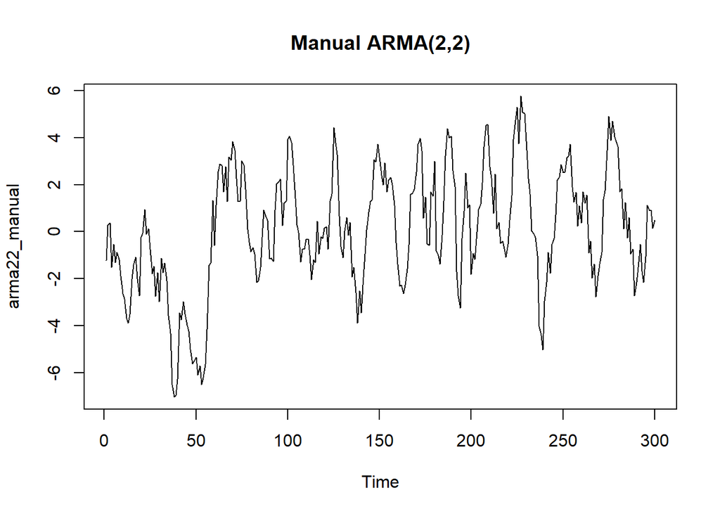

```r
ts.plot(arma22_manual, main="Manual ARMA(2,2)")
```

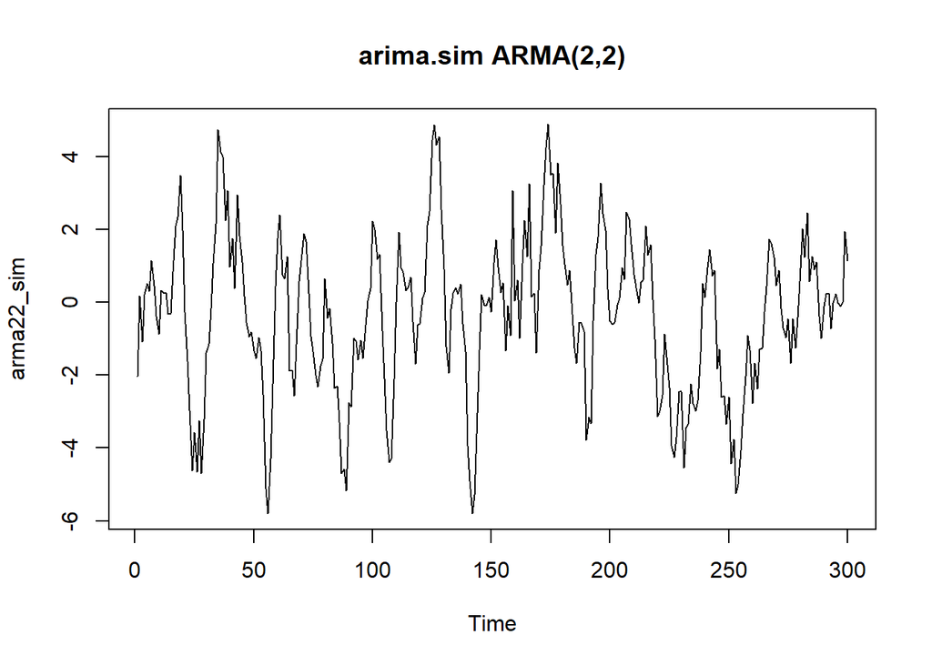

```r
ts.plot(arma22_sim, main="arima.sim ARMA(2,2)")
```

Berdasarkan plot time series tersebut, terlihat bahwa model ARMA(2,2) cenderung stasioner dalam rataan

### Plot ACF

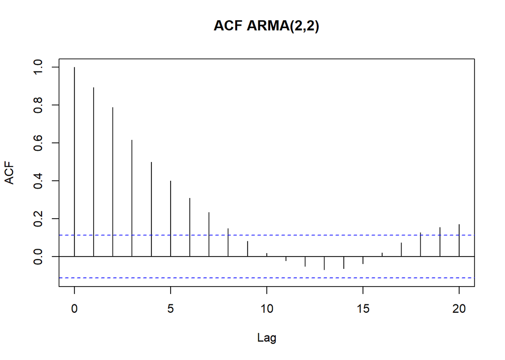

```r
acf(arma22_manual, lag.max=20, main="ACF ARMA(2,2)")
```

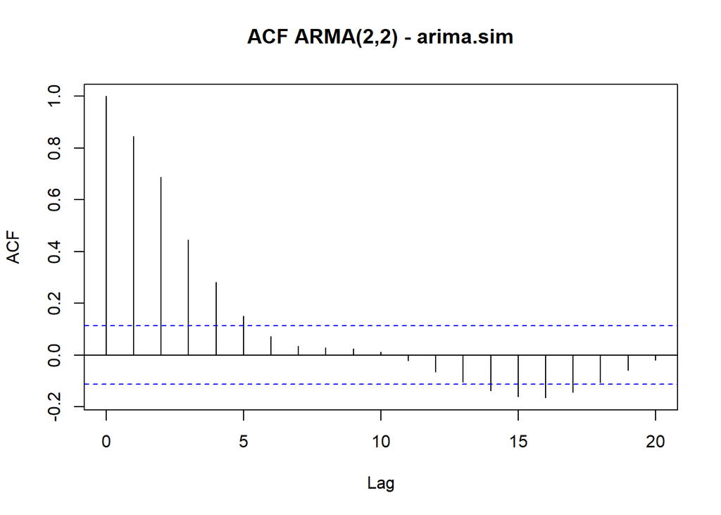

```r
acf(arma22_sim, lag.max=20, main="ACF ARMA(2,2) - arima.sim")
```

Berdasarkan plot ACF tersebut, terlihat bahwa model ARMA(2,2) hasil simulasi memiliki plot ACF yang *tails off*, sesuai dengan teori yang ada

### Plot PACF

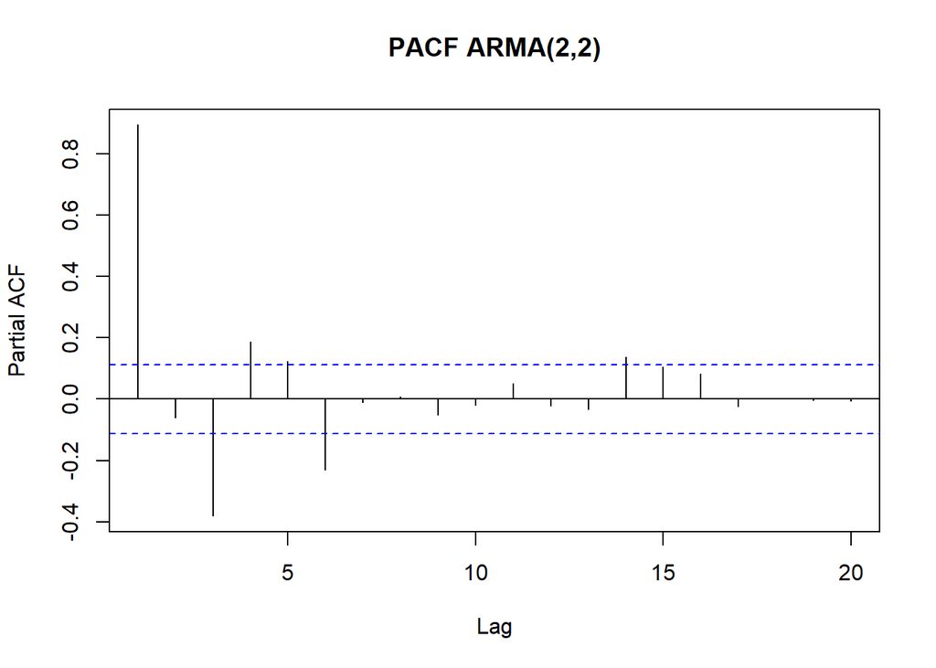

```r
pacf(arma22_manual, lag.max=20, main="PACF ARMA(2,2)")
```

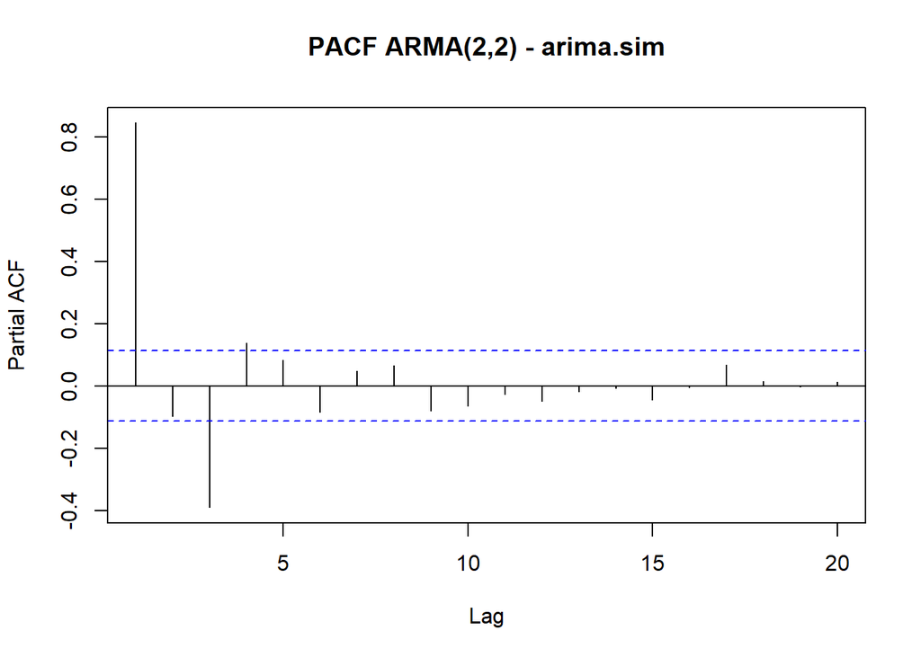

```r
pacf(arma22_sim, lag.max=20, main="PACF ARMA(2,2) - arima.sim")
```

Berdasarkan plot PACF tersebut, terlihat bahwa model ARMA(2,2) hasil simulasi memiliki plot PACF yang *tails off*, sesuai dengan teori

### Plot EACF

```r
TSA::eacf(arma22_manual)
```

```
## AR/MA
##   0 1 2 3 4 5 6 7 8 9 10 11 12 13
## 0 x x x x x x x x o o o  o  o  o
## 1 o x o o o o x o o o o  o  o  o
## 2 x x o o o o x o o o o  o  o  o
## 3 x x o x o o x o o o o  o  o  o
## 4 x x x x o o x o o o o  o  o  o
## 5 x x x x x x x o o o o  o  o  o
## 6 o o x o x x o o o o o  o  o  o
## 7 o o x o x x o x o o o  o  o  o
```

```r
TSA::eacf(arma22_sim)
```

```
## AR/MA
##   0 1 2 3 4 5 6 7 8 9 10 11 12 13
## 0 x x x x x o o o o o o  o  o  x
## 1 x x o o o o o o o o o  o  o  o
## 2 x x x x o o o o o o o  o  o  o
## 3 x x o x o o o o o o o  o  o  o
## 4 x x o x x o o o o o o  o  o  o
## 5 x x x x o o o o o o o  o  o  o
## 6 x x x x o x o o o o o  o  o  o
## 7 x x o x x x x o o o o  o  o  o
```

## Scatterplot Antar Lag

### Korelasi antara $Y_t$ dengan $Y_{t-1}$

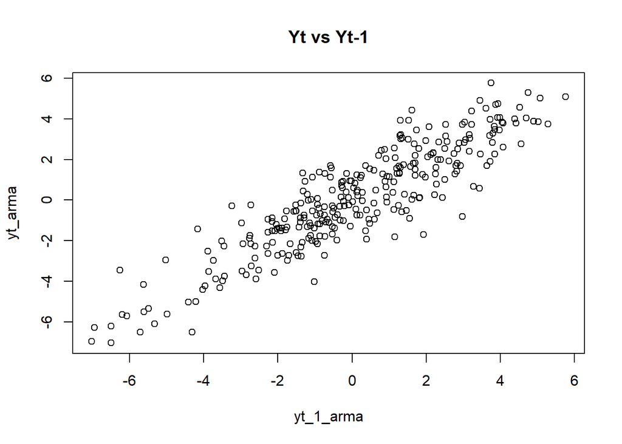

```r
yt_arma <- arma22_manual[-1]
yt_1_arma <- arma22_manual[-n]
plot(x=yt_1_arma, y=yt_arma, main="Yt vs Yt-1")
```

```r
cor(yt_arma, yt_1_arma)
```

```
## [1] 0.8946787
```

Korelasi antara $Y_t$ dengan $Y_{t-1}$ dari hasil simulasi mendekati perhitungan teoritis yaitu

$$\rho_1=0.8592$$

### Korelasi antara $Y_t$ dengan $Y_{t-2}$

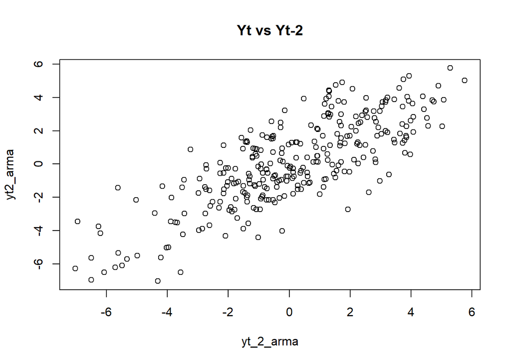

```r
yt2_arma <- arma22_manual[-c(1,2)]
yt_2_arma <- arma22_manual[-c((n-1), n)]
plot(x=yt_2_arma, y=yt2_arma, main="Yt vs Yt-2")
```

```r
cor(yt2_arma, yt_2_arma)
```

```
## [1] 0.78822
```

Korelasi antara $Y_t$ dengan $Y_{t-2}$ dari hasil simulasi mendekati perhitungan teoritis yaitu

$$\rho_2=0.7492$$

### Korelasi antara $Y_t$ dengan $Y_{t-3}$

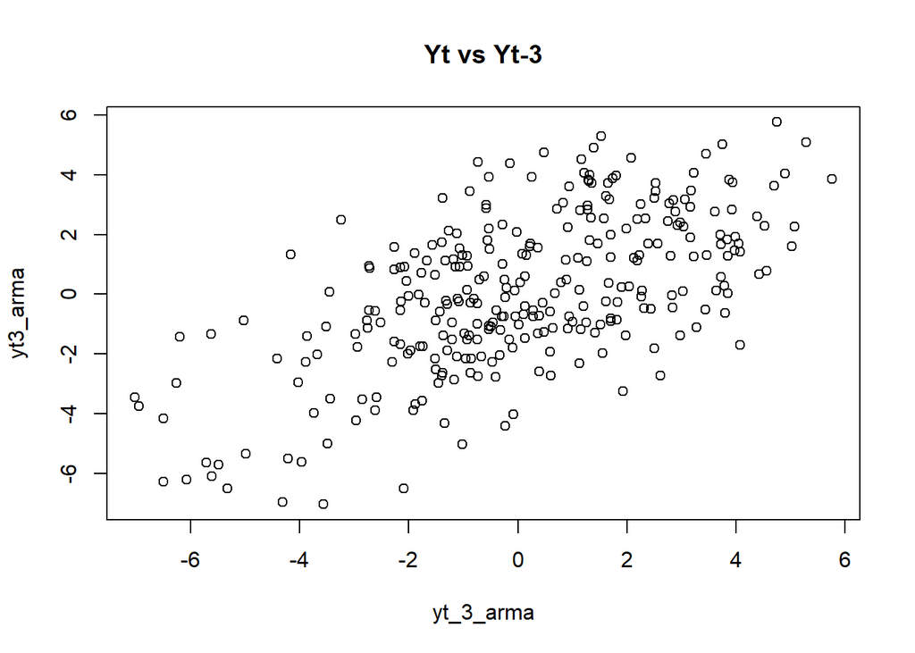

```r
yt3_arma <- arma22_manual[-c(1,2,3)]
yt_3_arma <- arma22_manual[-c((n-2), (n-1), n)]
plot(x=yt_3_arma, y=yt3_arma, main="Yt vs Yt-3")
```

```r
cor(yt3_arma, yt_3_arma)
```

```
## [1] 0.6177423
```

Korelasi antara $Y_t$ dengan $Y_{t-3}$ dari hasil simulasi mendekati perhitungan teoritis yaitu

$$\rho_3=0.5464$$

## Autokorelasi

```r
acf(arma22_manual, lag.max=10, plot=FALSE)$acf
```

```
## , , 1
##
##             [,1]
##  [1,] 1.00000000
##  [2,] 0.89425596
##  [3,] 0.78783999
##  [4,] 0.61732077
##  [5,] 0.49993844
##  [6,] 0.40089929
##  [7,] 0.31016176
##  [8,] 0.23367252
##  [9,] 0.14898757
## [10,] 0.08067289
## [11,] 0.01773312
```

```r
acf(arma22_sim, lag.max=10, plot=FALSE)$acf
```

```
## , , 1
##
##             [,1]
##  [1,] 1.00000000
##  [2,] 0.84539224
##  [3,] 0.68716196
##  [4,] 0.44503732
##  [5,] 0.28137061
##  [6,] 0.15115535
##  [7,] 0.07236801
##  [8,] 0.03531025
##  [9,] 0.02905171
## [10,] 0.02465017
## [11,] 0.01138468
```